# Sesion 14 - Diversificacion via mezclas

Juan Carlos Martínez-Ovando

Otoño 2019

# 1 Preliminares

> En la `sesion 13` estudiamos que de manera adicional a la informacion/datos de riesgos (datos acerca de la **frecuencia de siniestros** y de las severidades individuales **severidades individuales**), se puede incluir en el modelo informacion acerca de **variables auxiliares intrinsecas** para **diversidicar el riesgo** de un portafolio de seguros.

Asi, si las **variables auxiliares** son de tipo categoricas, de manera que una o combinacion de varias variables adicionales inducen la **segmentacion** del protafolio en $K$ categorias, entonces el portafolio de seguros puede modelarse via **modelos jerarquicos** con $K$-segmentos, i.e.
$$\begin{eqnarray}
Y_{ik}|k,\theta_k & \sim & F_k(y|\theta_k) \\
\theta_k & \sim & G(\theta|\gamma),
\end{eqnarray}$$
para $k=1,\ldots,K$ e $i=1,\ldots,I_k$, donde

- $F_k(y|\theta_k)$ es un modelo de probabilidad para el segmento de riesgo $k$, parametrizado por $\theta_k$ (esta distribucion mide la incertidumbre al interior del segmento)
- $G(\theta|\gamma)$ es un modelo de probabilidad para los parametros de todos los segmentos (esta distribucion mide la incertidumbre entre segmentos), a su vez parametrizada por $\gamma$ (parametro comun a todos los segmentos)
- se supone que $\theta_k\neq\theta_l$ para todo $k\neq l$ (para que la especificacion del modelo tenga sentido).

Adicionalmente, se supone que
$$\gamma \sim \Pi(\gamma),$$
cuantifica la informaion suplemental acerca de $\gamma$.

De manera que para todo $i$ y $k$ se tiene que el **modelo marginal**,
$$P(y|\gamma) = \int F_k(y|\theta_k)G(d \theta_k|\gamma),$$
es el mismo (por lo que en el agregado, el supuesto de `homogeniedad` se cumple).

> Recodemos que para que esto tenga sentido, la informacion de las variables auxiliares debe inducir que cada poliza pertenezca a uno y solo uno de los segmentos de riesgos distintos.

## 1.1 Observacion

> En muchas ocasiones, podemos sospechar que al interior del portafolio subyacen diferentes exposiciones al riesgo, pero **no es posible identificar** para una poliza particular a que riesgo corresponde.

En ese caso, la enumeracion de los $K$ segmentos de riesgo no existe, y la asignacion del tipo de riesgo a cada poliza tampoco es posible de realizar sin error.

En este caso, se recomienda manigestar en el modelo la posibilidad de asociar diferentes segmentos de riesgo para cada poliza empleando **mezclas de modelos**.

Las mezclas de modelos, quedan especificadas como
$$Y_{i} \sim F(y|\gamma),$$
donde
$$F(y|\gamma) = \sum_{l=1}^{L}w_l F_l(y|\theta_l),$$
con

- $F_l(y|\theta_l)$ cuantifica la incertidumbre al interior del **segmento de riesgo no revelado** $l$,
- $(w_1,\ldots,w_L)$ son valores en el simplejo de dimension $(L-1)$, y cuantifican la propension a que una poliza sea asociada con cada uno de los $L$ **segmentos se riesgo no revelados**.

Este modelo puede expresearse *jerarquicamente* incorporando una **variable de asginacion de segmento** $\iota$ a cada poliza, i.e.
$$\begin{eqnarray}
Y_i|\iota_i=l &\sim & F_l(y|\theta_l) \\
\iota_i & \sim & \text{Mult}(\iota|w_1,\ldots,w_L),
\end{eqnarray}$$
para $i=1,\ldots,I$.

> Cuando $L$ es **finito** se dice que se trabaja con modelos de **mezclas finitas**.

## 1.2 Estimacion

La estimacion de **modelos de mezclas finitas** puede realizase de la siguiente forma:

1. Caso frecuentista, via el `algoritmo EM` (Expectation-Maximization)
2. Caso bayesiano, via el `algoritmo Gibbs sampler`.

> en esta sesion haremos uso del `algoritmo EM`.

## 1.3 Caso general

> Mas aun, podemos pensar que cada uno de los riesgos asociados con las polizas, $Y_i$ para $i=1,\ldots,I$, puede esyar acompaniado con **informacion adicional revelada**, denotada por $z_i$ (puede ser multidimensional, categorica o numerica escalar), de manera que el modelo de probabilidad para $Y_i$ puede ser **dependiente en z_i**, de manera que
> $$Y_{i}|z_i \sim F(y|z_i,\gamma),$$
> donde
> $$F(y|z_i,\gamma) = \sum_{l=1}^{L}w_l F_l(y|z_i,\theta_l),$$
> con
- $F_l(y|z_i,\theta_l)$ cuantifica la incertidumbre al interior del **segmento de riesgo no revelado** $l$, indizada por $z_i$ (como un modelo de regresion, por ejemplo)
- $(w_1,\ldots,w_L)$ son valores en el simplejo de dimension $(L-1)$, y cuantifican la propension a que una poliza sea asociada con cada uno de los $L$ **segmentos se riesgo no revelados**.

> Estos modelos se conocen como **modelos de mezclas finitas de regresion**.

A continuacion veremos como implementar estos modelos en diferentes contextos.

# 2 Mezclas de regresion binomial

En este caso consideramos que la variable de interes, $Y_i$, es discreta en la forma de conteo o dicotomica, i.e.
$$Y_i|\iota_i=l \sim \text{Bin}(y|J,\theta_{il}),$$
donde
$$\begin{eqnarray}
\theta_{il} & = & \mathbb{P}(\text{siniestro}) \\
& = & g(\beta_l'z_i),
\end{eqnarray}$$
siendo $\beta_l$ un vector de coeficientes de regresion para el **segmento no evidente** $l$, y $z_i$ un conjunto de covariables.

Por otro lado,
$$\mathbb{P}\left(\iota_{i} = l\right) = w_l,$$
para todo $i$.

> Marginalizando $\iota_i$ tenemos
> $$Y_i \sim \sum_{l=1}^L w_l \text{Bin}(y|J,\theta_{il}).$$

## 2.1 Implementacion

Veamos como funciona este modelo en la practica. Los datos para implementar este tipo de modelos deben estar estructurados de la siguiente forma.

```r
if(!require("flexmix")){install.packages("flexmix")}
library("flexmix")

data("NregFix", package = "flexmix")

dim(NregFix)
```

```
## [1] 200   5
```

```r
tail(NregFix)
```

```
##              x1 x2 w          y class
## 195 -0.79439742  0 1   2.787228     3
## 196 -1.59917088  0 0 -15.747494     2
## 197  0.02752522  1 1   7.075196     3
## 198 -2.07885970  1 1   6.855008     3
## 199  1.96195349  1 1  15.722327     1
## 200  0.07206209  0 1   2.764006     2
```

```r
colnames(NregFix)
```

```
## [1] "x1"    "x2"    "w"     "y"     "class"
```

Con la siguiente instruccion indicaremos que **covariables** del `data.frame` `NregFix` consideraremos en el modelo.

```r
Model <- FLXMRglm(~ x2 + x1)
Model
```

```
## FlexMix model of type FLXMRglm:gaussian
##
## formula: ~x2 + x1
## Weighted likelihood possible: TRUE
```

La implementacion computacional del modelo via el `algoritmo EM` (i.e. via simulacion estocastica), se realiza de la siguiente forma:

```r
set.seed(12345)

fittedModel <- stepFlexmix(y ~ 1, model = Model,
                           nrep = 3, k = 3,
                           data = NregFix, concomitant = FLXPmultinom(~ w))
```

```
## 3 : * * *
```

```r
fittedModel
```

```
##
## Call:
## stepFlexmix(y ~ 1, model = Model, data = NregFix, concomitant = FLXPmultinom(~w),
##     k = 3, nrep = 3)
##
## Cluster sizes:
##  1  2  3
## 95 31 74
##
## convergence after 26 iterations
```

```r
fittedModel <- relabel(fittedModel, "model", "x1")

fittedModel
```

```
##
## Call:
## stepFlexmix(y ~ 1, model = Model, data = NregFix, concomitant = FLXPmultinom(~w),
##     k = 3, nrep = 3)
##
## Cluster sizes:
##  1  2  3
## 95 74 31
##
## convergence after 26 iterations
```

- En este caso, consideramos `k = 3` posibles clases.
- El modelo considera la inclusion de una ordenada al origen en el componente de regresion, por eso la especificacion `y ~ 1`.
- Con la funcion `relabel` se etiquetan de nuevo los grupos encontrados en la mezcla. Esto es por una consideracion de identificabilidad (se conoce a este tema como *label-switching problem*).

> El resumen de esta implementacion es como sigue:

```r
summary(refit(fittedModel))
```

```
## $Comp.1
##             Estimate Std. Error z value Pr(>|z|)
## (Intercept)  2.87060    0.13515 21.2405   <2e-16 ***
## x21          5.10189    0.20849 24.4707   <2e-16 ***
## x1           0.13343    0.10633  1.2548   0.2095
## ---
## Signif. codes:  0 '***' 0.001 '**' 0.01 '*' 0.05 '.' 0.1 ' ' 1
##
## $Comp.2
##             Estimate Std. Error z value  Pr(>|z|)
## (Intercept)  0.99360    0.18130  5.4803 4.246e-08 ***
## x21          5.28835    0.25233 20.9583 < 2.2e-16 ***
## x1           9.89241    0.11779 83.9862 < 2.2e-16 ***
## ---
## Signif. codes:  0 '***' 0.001 '**' 0.01 '*' 0.05 '.' 0.1 ' ' 1
##
## $Comp.3
##             Estimate Std. Error z value  Pr(>|z|)
## (Intercept) -7.64097    0.25162 -30.367 < 2.2e-16 ***
## x21          4.65180    0.38101  12.209 < 2.2e-16 ***
## x1           9.93672    0.16443  60.431 < 2.2e-16 ***
## ---
## Signif. codes:  0 '***' 0.001 '**' 0.01 '*' 0.05 '.' 0.1 ' ' 1
```

- Una `estimacion ingenua` de las probabilidades $(w_1,w_2,w_3)$ se obtendria a partir de los `Cluster sizes`, i.e
  $$\hat{w}_1 = 95 / 200, \\
  \hat{w}_2 = 74 / 200, \\
  \hat{w}_3 = 31 / 200. \\$$

## 2.2 Modelo complementario

Consideremos ahora un modelo complementario a `Model`. Este es etiquetado como `Model2`, el cual incluye ordenada al origen tambien (i.e. `y ~ 1`).

```r
Model2 <- FLXMRglmfix(fixed = ~ x2,
                      nested = list(k = c(1, 2),
                      formula = c(~ 0, ~ x1)), varFix = TRUE)

fittedModel2 <- flexmix(y ~ 1, model = Model2,
                        cluster = posterior(fittedModel),
                        data = NregFix,
                        concomitant = FLXPmultinom(~ w))
fittedModel2
```

```
##
## Call:
## flexmix(formula = y ~ 1, data = NregFix, cluster = posterior(fittedModel),
##     model = Model2, concomitant = FLXPmultinom(~w))
##
## Cluster sizes:
##  1  2  3
## 94 74 32
##
## convergence after 4 iterations
```

> Noten que la composicion de los grupos en `Model2` es marginalmente distinta.

El resumen de `Model2` es el siguiente:

```r
summary(refit(fittedModel2))
```

```
## $Comp.1
##             Estimate Std. Error z value  Pr(>|z|)
## x21          5.11133    0.14801  34.533 < 2.2e-16 ***
## (Intercept)  2.85755    0.12650  22.590 < 2.2e-16 ***
## ---
## Signif. codes:  0 '***' 0.001 '**' 0.01 '*' 0.05 '.' 0.1 ' ' 1
##
## $Comp.2
##             Estimate Std. Error  z value  Pr(>|z|)
## x21          5.11133    0.14801  34.5335 < 2.2e-16 ***
## x1           9.90234    0.09118 108.6027 < 2.2e-16 ***
## (Intercept)  1.07219    0.14188   7.5571  4.12e-14 ***
## ---
## Signif. codes:  0 '***' 0.001 '**' 0.01 '*' 0.05 '.' 0.1 ' ' 1
##
## $Comp.3
##             Estimate Std. Error z value  Pr(>|z|)
## x21          5.11133    0.14801  34.533 < 2.2e-16 ***
## x1           9.90234    0.09118 108.603 < 2.2e-16 ***
## (Intercept) -7.84837    0.19776 -39.687 < 2.2e-16 ***
## ---
## Signif. codes:  0 '***' 0.001 '**' 0.01 '*' 0.05 '.' 0.1 ' ' 1
```

> Observen que la especificacion de `Model2` permite identificar un conjunto de covariables potencialmente distinto al interior de los grupos (caso `Comp1`).

## 2.3 Comparacion de modelos

Habiendo implementado dos modelos que potencialmente resultan significativos y cuyas diferencias son sutiles y relevantes, la pregunta ahora reside en:

> Como elegir el **mejor modelo** entre estas alternativas.

Como vimos, criterior de bondad de ajuste en este caso no aplicarian, porque `Model` y `Model2` son estructuralmente distintos, siendo ambos bastante flexibles.

> El criterio que elegimos es basado en la **metrica de devianza**:

```r
BIC(fittedModel)
```

```
## [1] 883.5936
```

```r
BIC(fittedModel2)
```

```
## [1] 856.9122
```

> Que modelo elegiriamos???

# 3 Mezcla de regresion Gaussiana

En este caso, la variable de inetres es $Y_i$ con soporte en la recta real, y el modelo seria
$$Y_i \sim \sum_{l=1}^L w_l \text{N}(y|\mu_{il},\sigma^2_l),$$
donde
$$\mu_{il} = \beta_l'z_i.$$
* Este es el caso de mezclar $L$ modelos de regresion convencionales.

> Noten que el modelo es util para describir la variabilidad subyacente a las **severidades individuales** a traves de la transformacion de los montos asociada con la distribucion `logNormal`.

## 3.1 Implementacion

De igual forma, los datos deben estar estructurados como un `data.frame`.

```r
data("NPreg", package = "flexmix")

dim(NPreg)
```

```
## [1] 200   7
```

```r
colnames(NPreg)
```

```
## [1] "x"     "yn"    "yp"    "yb"    "class" "id1"   "id2"
```

```r
tail(NPreg)
```

```
##             x       yn yp yb class id1 id2
## 195 3.2461223 36.67280  4  0     2  98  49
## 196 3.6790372 47.78540  4  0     2  98  49
## 197 0.7316218 22.77809  2  1     2  99  50
## 198 6.6905571 37.59661  4  0     2  99  50
## 199 4.0849864 44.68387  1  0     2 100  50
## 200 9.1869290 22.40813  7  0     2 100  50
```

Ahora, implementamos la mezcla de dos componetes, i.e. $L=2$.

```r
Model.G <- flexmix(yn ~ x + I(x^2),
               data = NPreg, k = 2,
               control = list(verb = 5, iter = 100))
```

```
## Classification: weighted
##    5 Log-likelihood :    -723.3350
##   10 Log-likelihood :    -675.9951
##   15 Log-likelihood :    -642.5463
##   17 Log-likelihood :    -642.5453
```

```r
Model.G
```

```
##
## Call:
## flexmix(formula = yn ~ x + I(x^2), data = NPreg, k = 2, control = list(verb = 5,
##     iter = 100))
##
## Cluster sizes:
##   1   2
## 100 100
##
## convergence after 17 iterations
```

```r
summary(Model.G)
```

```
##
## Call:
## flexmix(formula = yn ~ x + I(x^2), data = NPreg, k = 2, control = list(verb = 5,
##     iter = 100))
##
##        prior size post>0 ratio
## Comp.1 0.506  100    141 0.709
## Comp.2 0.494  100    145 0.690
##
## 'log Lik.' -642.5453 (df=9)
## AIC: 1303.091   BIC: 1332.775
```

```r
summary(refit(Model.G))
```

```
## $Comp.1
##             Estimate Std. Error z value  Pr(>|z|)
## (Intercept) 14.71317    1.32377  11.115 < 2.2e-16 ***
## x            9.84833    0.59158  16.647 < 2.2e-16 ***
## I(x^2)      -0.96852    0.05526 -17.526 < 2.2e-16 ***
## ---
## Signif. codes:  0 '***' 0.001 '**' 0.01 '*' 0.05 '.' 0.1 ' ' 1
##
## $Comp.2
##              Estimate Std. Error z value Pr(>|z|)
## (Intercept) -0.208529   1.009206 -0.2066   0.8363
## x            4.814469   0.509610  9.4474   <2e-16 ***
## I(x^2)       0.036540   0.049755  0.7344   0.4627
## ---
## Signif. codes:  0 '***' 0.001 '**' 0.01 '*' 0.05 '.' 0.1 ' ' 1
```

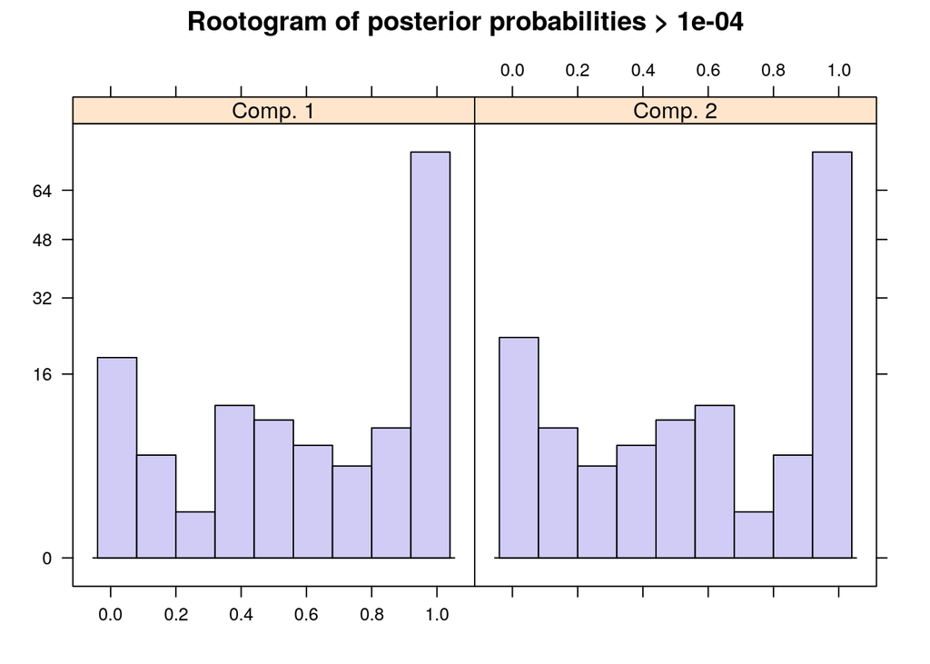

```r
plot(Model.G)
```

## 3.2 Modelo complementario

Al igual que en la ilustracion anterior, consideraremos ahora un modelo complementario **bastante loco** (por motivos ilustrativos), en el que:

1. Un componente es Gaussiano
2. Otro componente es Poisson.

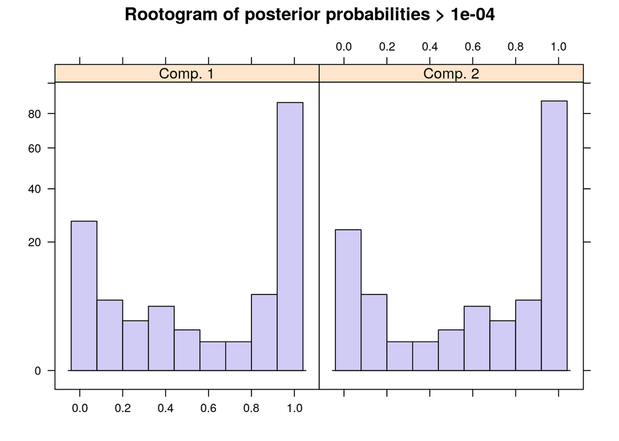

```r
Model3 <- flexmix(yn ~ x, data = NPreg, k = 2,
               model = list(FLXMRglm(yn ~ . + I(x^2)),
                            FLXMRglm(yp ~ ., family = "poisson")))
plot(Model3)
```

```r
Model3
```

```
##
## Call:
## flexmix(formula = yn ~ x, data = NPreg, k = 2, model = list(FLXMRglm(yn ~
##     . + I(x^2)), FLXMRglm(yp ~ ., family = "poisson")))
##
## Cluster sizes:
##   1   2
##  96 104
##
## convergence after 13 iterations
```

```r
table(Model3@cluster, NPreg$class)
```

```
##
##      1  2
##   1  1 95
##   2 99  5
```

> Los parametros asociados con el componente Gaussiano:

```r
parameters(Model3, component = 1, model = 1)
```

```
##                      Comp.1
## coef.(Intercept) 14.5911282
## coef.x            9.9151041
## coef.I(x^2)      -0.9757312
## sigma             3.4112369
```

> Los parametros asociados con el componente Poisson:

```r
parameters(Model3, component = 1, model = 2)
```

```
##                     Comp.1
## coef.(Intercept) 1.0377142
## coef.x           0.0910726
```

[output not shown]

# 4 Mezclas de regresion Poisson

Consideraremos ahora el caso en que la **variable de interes** es $Y_i$ con soporte en los enteros positivos, y consideramos que el modelo es de la forma
$$Y_i \sim \sum_{l=1}^L w_l \text{Po}(y|\lambda_{il}),$$
donde
$$\lambda_{il} = \exp\left\{ \beta_l ' z_i\right\}.$$

## 4.1 Implementacion

Al igual que antes, los datos deben estar estructurados como un `data.frame`:

```r
data("fabricfault", package = "flexmix")

dim(fabricfault)
```

```
## [1] 32  2
```

```r
colnames(fabricfault)
```

```
## [1] "Length" "Faults"
```

```r
tail(fabricfault)
```

```
##    Length Faults
## 27    735     17
## 28    749     10
## 29    495      7
## 30    716      3
## 31    952      9
## 32    417      2
```

```r
Model4 <- stepFlexmix(Faults ~ 1, model = FLXMRglmfix(family="poisson",
                                                         fixed = ~ log(Length)), data = fabricfault, k = 2, nrep = 3)
```

```
## 2 : * * *
```

```r
summary(Model4)
```

```
##
## Call:
## stepFlexmix(Faults ~ 1, model = FLXMRglmfix(family = "poisson",
##     fixed = ~log(Length)), data = fabricfault, k = 2, nrep = 3)
##
##        prior size post>0 ratio
## Comp.1 0.796   27     32 0.844
## Comp.2 0.204    5     32 0.156
##
## 'log Lik.' -86.3312 (df=4)
## AIC: 180.6624   BIC: 186.5253
```

```r
summary(refit(Model4))
```

```
## $Comp.1
##             Estimate Std. Error z value  Pr(>|z|)
## log(Length)  0.79913    0.23491  3.4019 0.0006692 ***
## (Intercept) -3.12797    1.51934 -2.0588 0.0395166 *
## ---
## Signif. codes:  0 '***' 0.001 '**' 0.01 '*' 0.05 '.' 0.1 ' ' 1
##
## $Comp.2
##             Estimate Std. Error z value  Pr(>|z|)
## log(Length)  0.79913    0.23491  3.4019 0.0006692 ***
## (Intercept) -2.36202    1.59146 -1.4842 0.1377593
## ---
## Signif. codes:  0 '***' 0.001 '**' 0.01 '*' 0.05 '.' 0.1 ' ' 1
```

## 4.2 Prediccion

> Recordemos que el proposito de estos modelos, con relacion a nuestro curso, es el de producir **predicciones** sobre valores futuros.

En el contexto de regresion, la prediccion se realiza de manera *mas o menos controlada*, considerando que a partir de **covariables**,
$$z_1^f,\ldots,z_m^f,$$
podemos general –a partir del modelo–, los **valores predictivos**
$$Y_1^f,\ldots,Y_m^f.$$
La generacion de valores predictivos, en el caso de mezclas, se obtiene facilmente de la siguiente forma:

```r
Znew <- seq(0, 1000, by = 50)

fabricMix.pred <- predict(Model4, newdata = data.frame(Length = Znew))

head(fabricMix.pred)
```

```
## $Comp.1
##               [,1]
##  [1,] 2.220446e-16
##  [2,] 9.924298e-01
##  [3,] 1.729243e+00
##  [4,] 2.392894e+00
##  [5,] 3.013092e+00
##  [6,] 3.602860e+00
##  [7,] 4.169459e+00
##  [8,] 4.717491e+00
##  [9,] 5.250113e+00
## [10,] 5.769619e+00
## [11,] 6.277744e+00
## [12,] 6.775845e+00
## [13,] 7.265007e+00
```

[output cut: 32 more lines]

### 4.2.1 Considerando el modelo complementario

```r
fabricMix2 <- flexmix(Faults ~ 0,
                      data = fabricfault,
                      cluster = posterior(Model4),
                      model = FLXMRglmfix(family = "poisson", fixed = ~ log(Length),
                                          nested = list(k=c(1,1), formula=list(~0,~1))))

summary(refit(fabricMix2))
```

```
## $Comp.1
##             Estimate Std. Error z value  Pr(>|z|)
## log(Length) 0.308000   0.013437  22.922 < 2.2e-16 ***
## ---
## Signif. codes:  0 '***' 0.001 '**' 0.01 '*' 0.05 '.' 0.1 ' ' 1
##
## $Comp.2
##             Estimate Std. Error z value  Pr(>|z|)
## log(Length) 0.308000   0.013437 22.9215 < 2.2e-16 ***
## (Intercept) 0.921282   0.132720  6.9415 3.878e-12 ***
## ---
## Signif. codes:  0 '***' 0.001 '**' 0.01 '*' 0.05 '.' 0.1 ' ' 1
```

```r
fabricMix2.pred <-  fabricMix2.pred <- predict(fabricMix2,
                                               newdata = data.frame(Length = Znew))
head(fabricMix2.pred)
```

```
## $Comp.1
##               [,1]
##  [1,] 2.220446e-16
##  [2,] 3.336194e+00
##  [3,] 4.130123e+00
##  [4,] 4.679460e+00
##  [5,] 5.112986e+00
##  [6,] 5.476727e+00
##  [7,] 5.793052e+00
##  [8,] 6.074714e+00
##  [9,] 6.329746e+00
## [10,] 6.563572e+00
## [11,] 6.780048e+00
## [12,] 6.982017e+00
## [13,] 7.171650e+00
```

[output cut: 32 more lines]

> Noten que las predicciones pueden ser significativamente distintas, en algunos casos.

> Por eso, necesitamos ser cuidadosos con la especificacion y eleccion del modelo para prediccion.

# 5 Lecturas complementarias

- Frühwirth-Schnatter, Sylvia, *Finite Mixture and Markov Switching Models*, Springer 2006.
- Ferrari & Cribari-Neto. *Beta Regression for Modeling Rates and Proportions.* Journal of Applied Statistics, 2004.
- Simas et al. *Improved Estimators for a General Class of Beta Regression Models.* Computational Statistics & Data Analysis, 2010.